# Topic 6: Topic Analysis

### Assignment:

Either:

1. continue on with the analysis we started (choose diff values for k and justify the decision for that k-value):

Run three more models and select the overall best value for k (the number of topics) - include some justification for your selection: theory, FindTopicsNumber() optimization metrics, interpretability, LDAvis

### Assignment Model #1

For my first experimental value of `k`, I will test out `k` = 3 because each of the EPA’s priority areas seem to fall into one of three main categories: rules and regulations, science and moniroing, and culture and humanities. I would expect to see the most words in the rules and regulations category, because the EPA is focused on that the most, while I expect the least to fall into the culture and humanities section. I think that manually choosing a value of `k` gives me a better understanding of the workflow without having a function choose the best value of `k` right off the bat. This value of `k` is small relative to the values we chose in class. Next, I will use a much larger `k` and compare results.

```r
k <- 3

topicModel_k3 <- LDA(dfm, k, method="Gibbs", control=list(iter = 500, verbose = 25))
```

```
## K = 3; V = 2781; M = 77
## Sampling 500 iterations!
## Iteration 25 ...
## Iteration 50 ...
## Iteration 75 ...
## Iteration 100 ...
## Iteration 125 ...
## Iteration 150 ...
## Iteration 175 ...
## Iteration 200 ...
## Iteration 225 ...
## Iteration 250 ...
## Iteration 275 ...
## Iteration 300 ...
## Iteration 325 ...
## Iteration 350 ...
## Iteration 375 ...
## Iteration 400 ...
## Iteration 425 ...
## Iteration 450 ...
## Iteration 475 ...
## Iteration 500 ...
## Gibbs sampling completed!
```

```r
tmResult <- posterior(topicModel_k3)

attributes(tmResult)
```

```
## $names
## [1] "terms"  "topics"
```

```r
beta <- tmResult$terms   # get beta from results
dim(beta)                # K distributions over nTerms(DTM) terms# lengthOfVocab
```

```
## [1]    3 2781
```

```r
terms(topicModel_k3, 30)
```

```
##       Topic 1      Topic 2     Topic 3
##  [1,] "communiti"  "communiti" "communiti"
##  [2,] "right"      "pollut"    "state"
##  [3,] "peopl"      "impact"    "framework"
##  [4,] "civil"      "air"       "draft"
##  [5,] "prison"     "health"    "agenc"
##  [6,] "project"    "state"     "permit"
##  [7,] "health"     "also"      "comment"
##  [8,] "can"        "comment"   "action"
##  [9,] "work"       "provid"    "feder"
## [10,] "comment"    "enforc"    "program"
## [11,] "need"       "requir"    "agenda"
## [12,] "citi"       "rule"      "use"
## [13,] "one"        "agenc"     "overburden"
## [14,] "water"      "popul"     "consid"
```

[output cut: 16 more lines]

### Assigment Model #2

```r
k <- 15

# feed in the DFM and the num of topics to look for and number of iterations, this function estimates the 2 matrices
topicModel_k15 <- LDA(dfm, k, method="Gibbs", control=list(iter = 500, verbose = 25))
```

```
## K = 15; V = 2781; M = 77
## Sampling 500 iterations!
## Iteration 25 ...
## Iteration 50 ...
## Iteration 75 ...
## Iteration 100 ...
## Iteration 125 ...
## Iteration 150 ...
## Iteration 175 ...
## Iteration 200 ...
## Iteration 225 ...
## Iteration 250 ...
## Iteration 275 ...
## Iteration 300 ...
## Iteration 325 ...
## Iteration 350 ...
## Iteration 375 ...
## Iteration 400 ...
## Iteration 425 ...
## Iteration 450 ...
## Iteration 475 ...
## Iteration 500 ...
## Gibbs sampling completed!
```

```r
tmResult <- posterior(topicModel_k15)

attributes(tmResult)
```

```
## $names
## [1] "terms"  "topics"
```

```r
beta <- tmResult$terms   # get beta from results
dim(beta)                # K distributions over nTerms(DTM) terms# lengthOfVocab
```

```
## [1]   15 2781
```

```r
terms(topicModel_k15, 10)
```

```
##       Topic 1         Topic 2    Topic 3    Topic 4     Topic 5     Topic 6
##  [1,] "juli"          "prison"   "thank"    "program"   "framework" "permit"
##  [2,] "energi"        "farmwork" "comment"  "feder"     "draft"     "state"
##  [3,] "site"          "pesticid" "need"     "state"     "communiti" "consid"
##  [4,] "infrastructur" "sourc"    "help"     "polici"    "state"     "grant"
##  [5,] "gas"           "health"   "subject"  "requir"    "epa"       "use"
##  [6,] "may"           "exposur"  "strategi" "implement" "comment"   "feder"
##  [7,] "counti"        "impact"   "work"     "may"       "action"    "air"
##  [8,] "project"       "project"  "sent"     "follow"    "agenc"     "carolina"
##  [9,] "access"        "facil"    "like"     "epa"       "effort"    "opportun"
## [10,] "ohio"          "contamin" "lung"     "tribe"     "agenda"    "meet"
##       Topic 7  Topic 8     Topic 9    Topic 10   Topic 11    Topic 12
##  [1,] "health" "communiti" "water"    "rule"     "agenc"     "communiti"
##  [2,] "park"   "plan"      "econom"   "state"    "action"    "pollut"
##  [3,] "peopl"  "use"       "increas"  "popul"    "program"   "comment"
```

[output cut: 18 more lines]

### Assignment Model #3

For the final model for this data, I will use the function `FindTopicsNumber()` to help me visualize the best value of `k`, but I will change it from the class code by adjusting the `topics` argument.

```r
# result <- FindTopicsNumber(
#   dfm,
#   topics = seq(from = 2, to = 20, by = 1),
#   metrics = c("CaoJuan2009",  "Deveaud2014"),
#   method = "Gibbs",
#   control = list(seed = 77),
#   verbose = TRUE
# )

# fit the model by running a series of models, starting with 2 topics and ranging to 20 topics
result <- FindTopicsNumber(
  dfm,
  topics = seq(from = 5, to = 30, by = 1),
  metrics = c("CaoJuan2009",  "Deveaud2014"),
  method = "Gibbs",
  control = list(seed = 100),
  verbose = TRUE
)
```

```
## fit models... done.
## calculate metrics:
##   CaoJuan2009... done.
##   Deveaud2014... done.
```

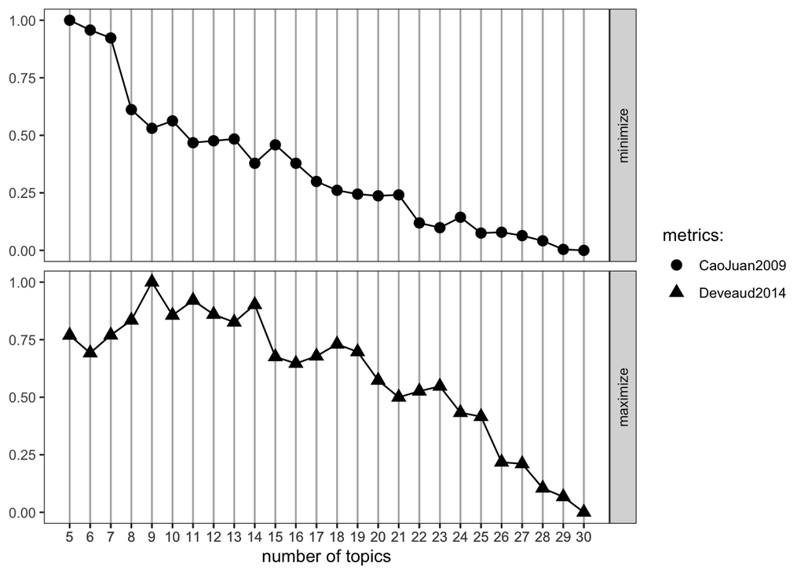

```r
FindTopicsNumber_plot(result)
```